# Repeated Measures OneWay ANOVA

```r
library(tidyverse)
library(emmeans)
library(rstatix)
```

# Example from the Chaper 8 Daniel

Licciardone et al. examined subjects with chronic, nonspecific low back pain. In this study, 18 of the subjects completed a survey questionnaire assessing physical functioning at baseline, and after 1, 3, and 6 months. File EXA_C08_S04_01.csv includes the data for these subjects who received a sham treatment that appeared to be genuine osteopathic manipulation. Higher values indicate better physical functioning. The goal of the experiment was to determine if subjects would report improvement over time even though the treatment they received would provide minimal improvement. We wish to know if there is a difference in the mean survey values among the four points in time.

## Data wrangling

After loading the dataset we notice that it is formated in table format and need to be changed to ‘longer’ format using the `pivot_longer` and selecting the variables and setting the subject label apart, since the subject label is used for the repeated measures ANOVA function.

```r
# Repeated measures One-Way ANOVA
chronPain <- read_csv("~/Dropbox/GitHub/ProbEstad/DataSets/ch08_all/EXA_C08_S04_01.csv", col_names = TRUE, show_col_types = FALSE)

chronPain_long <- chronPain %>%
  pivot_longer(cols = Baseline:Month6, names_to = "TreatmentT", values_to = "APhFq")

chronPain_long
```

```
## # A tibble: 72 × 3
##    Subject TreatmentT APhFq
##      <dbl> <chr>      <dbl>
##  1       1 Baseline      80
##  2       1 Month1        60
##  3       1 Month3        95
##  4       1 Month6       100
##  5       2 Baseline      95
##  6       2 Month1        90
##  7       2 Month3        95
##  8       2 Month6        95
##  9       3 Baseline      65
## 10       3 Month1        55
## # … with 62 more rows
```

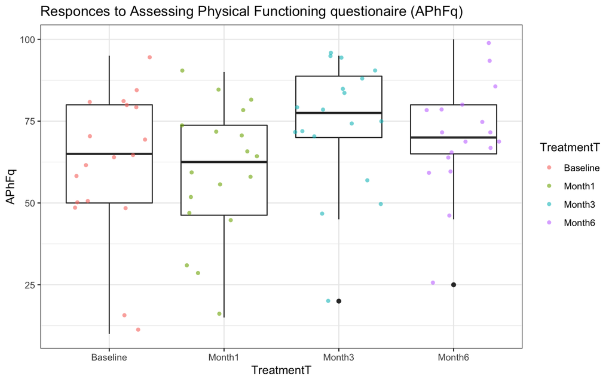

```r
chronPain_long <- chronPain_long %>%
  mutate( Subject = factor(Subject), TreatmentT = factor(TreatmentT) )

chronPain_long <- chronPain_long %>%
  mutate( TreatmentT = TreatmentT %>% fct_relevel("Baseline","Month1","Month3","Month6") )

# A boxplot
chronPain_long %>% ggplot(aes(x = TreatmentT, y = APhFq)) +
    geom_boxplot() +
    geom_jitter(aes(colour = TreatmentT), shape = 16, position = position_jitter(seed = 123), alpha = 0.6) +
    labs(title = "Responces to Assessing Physical Functioning questionaire (APhFq)") +
    theme_bw()
```

## Repated Measures ANOVA model

We will estimate the model with the base library `aov()` function and the `emmeans` function to estimate the *post hoc* adjusted probability values and the pairwise differences (Tukey) and plots.

```r
#
# first load the missing libraries
# library(car)

# Testing for outliers
chronPain_long %>%
  group_by(TreatmentT) %>%
  identify_outliers(APhFq)
```

```
## # A tibble: 2 × 5
##   TreatmentT Subject APhFq is.outlier is.extreme
##   <fct>      <fct>   <dbl> <lgl>      <lgl>
## 1 Month3     16         20 TRUE       FALSE
## 2 Month6     16         25 TRUE       FALSE
```

```r
# Test normal distribution
chronPain_long %>%
  group_by(TreatmentT) %>%
  shapiro_test(APhFq)
```

```
## # A tibble: 4 × 4
##   TreatmentT variable statistic      p
##   <fct>      <chr>        <dbl>  <dbl>
## 1 Baseline   APhFq        0.900 0.0568
## 2 Month1     APhFq        0.960 0.611
## 3 Month3     APhFq        0.884 0.0303
## 4 Month6     APhFq        0.935 0.235
```

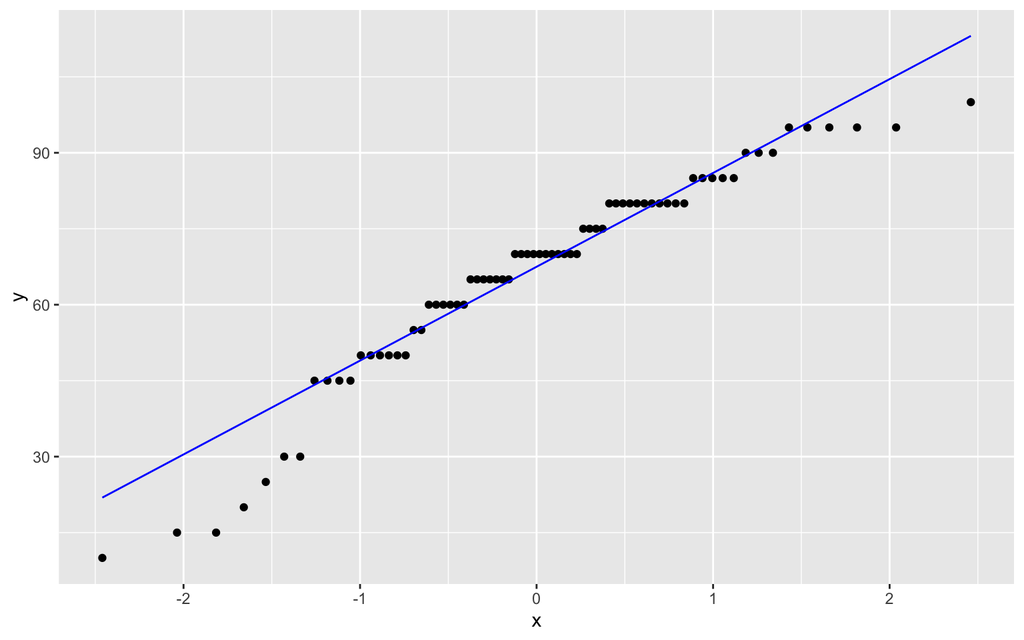

```r
chronPain_long %>%
  group_by(TreatmentT) %>%
  ggplot(aes(sample = APhFq)) +
  geom_qq() +
  geom_qq_line(color = "blue")
```

```r
# With the aov R function
chronPain_long_aov <- aov( APhFq ~ TreatmentT + Error(Subject/TreatmentT),
                            data = chronPain_long )
#
summary(chronPain_long_aov)
```

```
##
## Error: Subject
##           Df Sum Sq Mean Sq F value Pr(>F)
## Residuals 17  20237    1190
##
## Error: Subject:TreatmentT
##            Df Sum Sq Mean Sq F value  Pr(>F)
## TreatmentT  3   2396   798.6   5.501 0.00237 **
## Residuals  51   7404   145.2
## ---
## Signif. codes:  0 '***' 0.001 '**' 0.01 '*' 0.05 '.' 0.1 ' ' 1
```

```r
# To estimate the pairwise post hoc
emmeans_aov <- emmeans(chronPain_long_aov, ~ TreatmentT)
```

```
## Note: re-fitting model with sum-to-zero contrasts
```

```r
pairs(emmeans_aov)
```

```
##  contrast          estimate   SE df t.ratio p.value
##  Baseline - Month1     2.50 4.02 51   0.622  0.9244
##  Baseline - Month3   -11.67 4.02 51  -2.905  0.0269
##  Baseline - Month6    -8.06 4.02 51  -2.006  0.1994
##  Month1 - Month3     -14.17 4.02 51  -3.527  0.0048
##  Month1 - Month6     -10.56 4.02 51  -2.628  0.0534
##  Month3 - Month6       3.61 4.02 51   0.899  0.8053
##
## P value adjustment: tukey method for comparing a family of 4 estimates
```

```r
pwpm(emmeans_aov)
```

```
##          Baseline Month1 Month3 Month6
## Baseline   [61.9] 0.9244 0.0269 0.1994
## Month1       2.50 [59.4] 0.0048 0.0534
## Month3     -11.67 -14.17 [73.6] 0.8053
## Month6      -8.06 -10.56   3.61 [70.0]
##
## Row and column labels: TreatmentT
## Upper triangle: P values   adjust = "tukey"
## Diagonal: [Estimates] (emmean)
## Lower triangle: Comparisons (estimate)   earlier vs. later
```

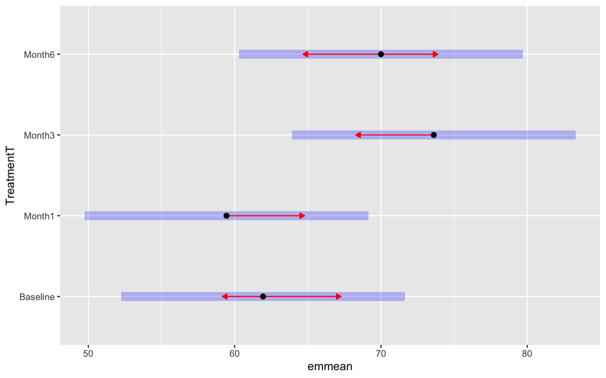

```r
plot(emmeans_aov, comparisons = TRUE)
```

## Using the `rstatix`

For using the anova function of `rstatix` library, the data can be “piped” and the *post hoc* handling is more complicated, the paired t-test is used the estimate de adjusted differences from baseline.

```r
# ANOVA test from the rstatix pack
chronPain_long_aTest <- chronPain_long %>% anova_test(dv = APhFq, wid = Subject, within = TreatmentT)
get_anova_table(chronPain_long_aTest)
```

```
## ANOVA Table (type III tests)
##
##       Effect  DFn   DFd     F     p p<.05  ges
## 1 TreatmentT 2.22 37.68 5.501 0.006     * 0.08
```

```r
# Pairwise comparisons
paired_chronPain <- chronPain_long %>%
  pairwise_t_test(APhFq ~ TreatmentT , paired = TRUE, p.adjust.method = "bonferroni")

data.frame(paired_chronPain)
```

```
##     .y.   group1 group2 n1 n2  statistic df     p p.adj p.adj.signif
## 1 APhFq Baseline Month1 18 18  0.6583523 17 0.519 1.000           ns
## 2 APhFq Baseline Month3 18 18 -2.7150841 17 0.015 0.088           ns
## 3 APhFq Baseline Month6 18 18 -1.7468985 17 0.099 0.592           ns
## 4 APhFq   Month1 Month3 18 18 -3.8643409 17 0.001 0.007           **
## 5 APhFq   Month1 Month6 18 18 -2.2237818 17 0.040 0.240           ns
## 6 APhFq   Month3 Month6 18 18  1.3984821 17 0.180 1.000           ns
```

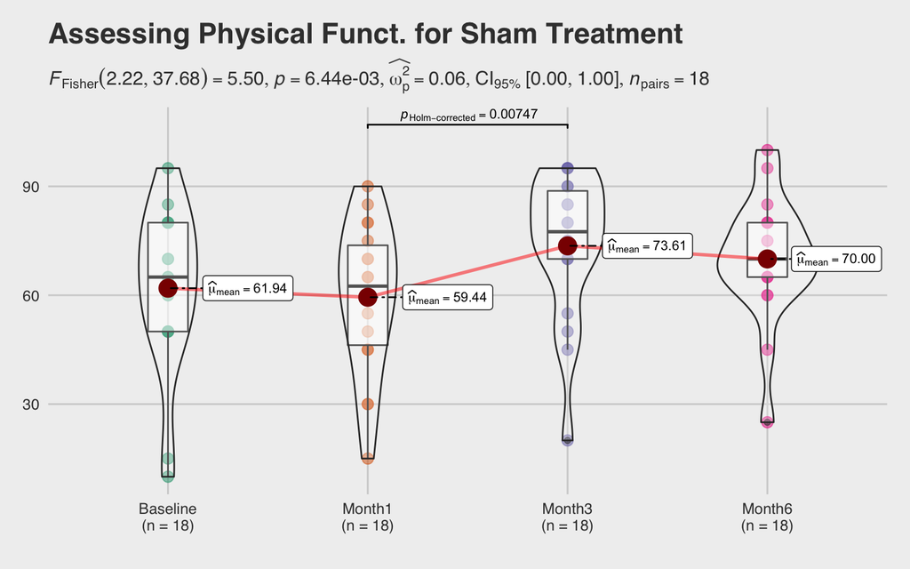

```r
# # # # # # # # # # # # # # # # # #

# for reproducibility and data
set.seed(123)
library(ggstatsplot)
library(afex) # to run anova
# plot
ggwithinstats(
  data = chronPain_long,
  x = TreatmentT,
  y = APhFq,
  title = "Assessing Physical Funct. for Sham Treatment",
  caption = "Data source: Daniel ch 8",
  ggtheme = ggthemes::theme_fivethirtyeight()
)
```